# Introduction to Multiple Linear Regression with R

This file contains R-codes to run multiple regression on a clean dataset. It assumes minimal prior knowledge of R. To use it directly, download and run this file in R-Studio (with R already installed in the machine). Remeber to change the file names / paths etc. wherever required.

While using R, resources like data sets can be accessed from anywhere in your system and from the internet too. But for beginners, it helps to keep everything in one folder. This folder is called a ‘working directory’ (wd). By default, the program searches for resources and saves output from instructions in the wd. The following codes will print the name and path to the current wd. It can set a folder of your choice as the wd.

Note thet if a line starts with ‘#’ within a code chunk (as in the one below) it will not be executed. The line if treated as as a comment or text.

```r
# Get and print current working directory.
print(getwd())

# Set current working directory.
#setwd("E:\\rfiles\\exercise1") #write the path of your wd within " "
#Note the use of \\ or / in place of \ in the path. Relevant for windows systems
```

### THE BUSINESS PROBLEM

Suppose that you are asked to provide advice on how to improve sales of a particular product. The company has some recent data on effect of advertisement on its sales. The data set consists of the sales of that product in 200 different markets, along with advertising spends for the product in each of those markets for three different media: TV, radio, and newspaper.

The company can control the three marketing mix variables and hope to increase sales through them. What are the best levels for advertisement in these mediums?

The data needs to be loaded on R environment before analysis. Reading CSV file is the easiest among all file formats in R. Other formats can be handled easily too. There are libraries like ‘readXL’ that simplify reading data from excel file formats. Our data is in CSV format.

```r
mydata <- read.csv("advertising.csv")
head(mydata)
#prints the first few rows of the dataset. You can view the complete dataset on a spreadsheet by double clicking on the file name in the environment window
```

You may not need in the dataset, the first column (i.e. variable X). It can be dropped using the following codes

```r
mydata <- within(mydata, rm(X))
```

Inspect the dataframe as a table and print variable names.

```r
fix(mydata)
# outputting data column names
names(mydata)
# outputting data
write.table(mydata)
```

Search if the data has any missing values. Many procedures do not work if the data has missing values or special instructions need to be given when they are present.

```r
##Number of missing values (NAs) in the dataframe
sum(is.na(mydata))
## Identify NAs in full data frame
#is.na(mydata)
## Identify NAs in specific data frame column
#is.na(mydata$TV)
##To compute the total missing values in each column is to use colSums()
#colSums(is.na(mydata))
##Simple ways to deal with missing value https://uc-r.github.io/missing_values
# Fastest way to remove na - remove all rows with na
#mydata <- na.omit(mydata)
```

Now the data is ready for analysis. It is always a good idea to start with exploratory data analysis techniques.

```r
#To print the variable names and type of data under each variable
str(mydata)
```

Plot the data for each column to get a feel for it as well as a histogram to see the data distribution

```r
#
#loading packages
require("ggplot2")

plot(mydata$Sales)
hist(mydata$Sales)

plot(mydata$TV)
hist(mydata$TV)
plot(mydata$TV, mydata$Sales)

plot(mydata$Radio)
hist(mydata$Radio)
plot(mydata$Radio, mydata$Sales)

plot(mydata$Newspaper)
hist(mydata$Newspaper)
plot(mydata$Newspaper, mydata$Sales)
```

For descriptive statistics, the function ‘summary’ can be used. The package ‘pastecs’ is used below for a more detailed output. Do check for missing values and type of variable (must be numeric).

```r
# Compute descriptive statistics
library(pastecs)
res <- stat.desc(mydata)
round(res, 2)
```

Pearson’s linear correlation coefficient measures the extent of linear relationship between two variables.

```r
# Correlation matrix and respective p-values
library("Hmisc")
res2 <- rcorr(as.matrix(mydata))
res2
```

Evaluate the linear relationship further between two variables by building simple linear regression model

```r
fit1 <- lm(Sales~TV, data = mydata)
summary(fit1)
```

```
Call:
lm(formula = Sales ~ TV, data = mydata)

Residuals:
    Min      1Q  Median      3Q     Max
-8.3860 -1.9545 -0.1913  2.0671  7.2124

Coefficients:
            Estimate Std. Error t value Pr(>|t|)
(Intercept) 7.032594   0.457843   15.36   <2e-16 ***
TV          0.047537   0.002691   17.67   <2e-16 ***
---
Signif. codes:  0 ‘***’ 0.001 ‘**’ 0.01 ‘*’ 0.05 ‘.’ 0.1 ‘ ’ 1

Residual standard error: 3.259 on 198 degrees of freedom
Multiple R-squared:  0.6119,    Adjusted R-squared:  0.6099
F-statistic: 312.1 on 1 and 198 DF,  p-value: < 2.2e-16
```

```r
confint(fit1) #Confidence interval estimates
```

```
                 2.5 %     97.5 %
(Intercept) 6.12971927 7.93546783
TV          0.04223072 0.05284256
```

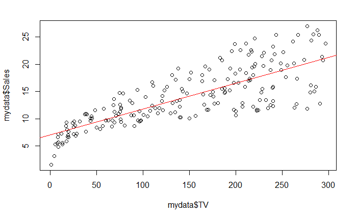

```r
plot(mydata$TV, mydata$Sales)
abline(lm(mydata$Sales~mydata$TV),col='red')
```

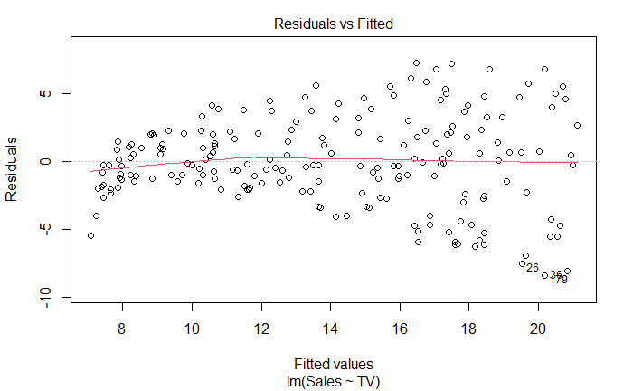

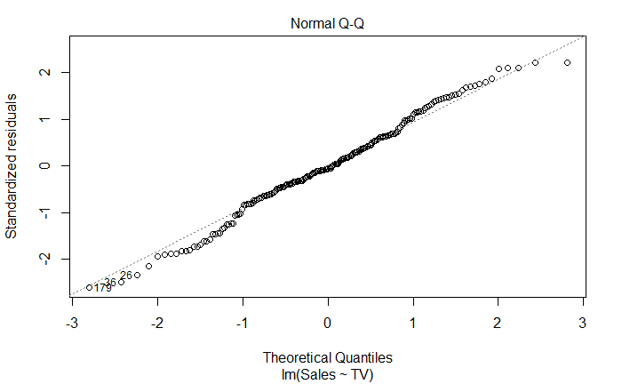

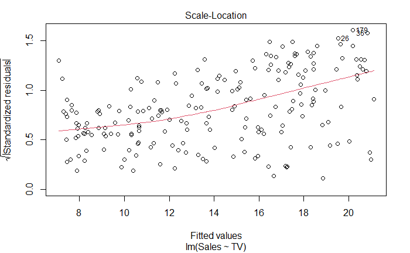

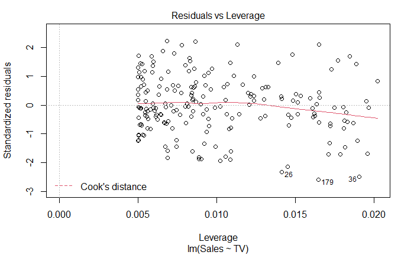

```r
plot(fit1)
```

Estimate the multiple linear regression model.

```r
# Multiple Linear Regression
lm.fit=lm(Sales ~ TV + Radio + Newspaper, data = mydata)
summary(lm.fit)
```

```
Call:
lm(formula = Sales ~ TV + Radio + Newspaper, data = mydata)

Residuals:
    Min      1Q  Median      3Q     Max
-8.8277 -0.8908  0.2418  1.1893  2.8292

Coefficients:
             Estimate Std. Error t value Pr(>|t|)
(Intercept)  2.938889   0.311908   9.422   <2e-16 ***
TV           0.045765   0.001395  32.809   <2e-16 ***
Radio        0.188530   0.008611  21.893   <2e-16 ***
Newspaper   -0.001037   0.005871  -0.177     0.86
---
Signif. codes:  0 ‘***’ 0.001 ‘**’ 0.01 ‘*’ 0.05 ‘.’ 0.1 ‘ ’ 1

Residual standard error: 1.686 on 196 degrees of freedom
Multiple R-squared:  0.8972,    Adjusted R-squared:  0.8956
F-statistic: 570.3 on 3 and 196 DF,  p-value: < 2.2e-16
```

Verify the if the use of multiple linear regression is correct. For this, check the assumptions on multicollinearity, normality of residuals, homeskedasticity etc. are corect. VIF is the variance infation factor. It provides information of possible multicollineaity

```r
library(car)
vif(lm.fit)
```

```
       TV     Radio Newspaper
 1.004611  1.144952  1.145187
```

```r
sales_pred <- predict(lm.fit)
head(sales_pred)
```

```
       1        2        3        4        5        6
20.52397 12.33785 12.30767 17.59783 13.18867 12.47835
```

```r
sales_resid <- residuals(lm.fit)
head(sales_resid)
```

```
         1          2          3          4          5          6
 1.5760256 -1.9378548 -3.0076708  0.9021705 -0.2886719 -5.2783476
```

### Regression diagnostics 1

```r
qqnorm(lm.fit$residuals)
qqline(lm.fit$residuals)
```

[output not shown]

## Testing for the assumption of Homoscedasticity.

### Null hypothesis : Residuals are homoscedastic.

### Alternate hypothesis : Residuals are not homoscedastic.

```r
lmtest::bptest(lm.fit)  # Breusch-Pagan test
car::ncvTest(lm.fit)
```

[output not shown]

Are there unusual observations? Interpret and discuss.

```r
#Single variable analysis through box-plots
outlier_values <- boxplot.stats(mydata$Sales)$out  # outlier values.
outlier_values
boxplot(mydata$Sales, main="Sales", boxwex=0.1)
mtext(paste("Outliers: ", paste(outlier_values, collapse=", ")), cex=0.6)
```

Data sets can sometimes contain outliers that are suspected to be anomalies (perhaps because of data collection errors or just plain old flukes). If outliers are present, the whisker on the appropriate side is drawn to 1.5 * Inter Quartile Range (IQR) rather than the data minimum or the data maximum. Small circles or unfilled dots are drawn on the chart to indicate where suspected outliers lie. Filled circles are used for known outliers. (http://r-statistics.co/Outlier-Treatment-With-R.html)

### Using Regression as a Machine Learning / Supervised Learning Tool

```r
library(dplyr)
set.seed(2)
mydata_train <- mydata %>%
 mutate(id = row_number()) %>%
 sample_frac(size = 0.8) #Allots 80% of the rows to train data sets
mydata_test <- mydata %>%
 mutate(id = row_number()) %>%
 # return all rows from mydata where there are not matching values in mydata_train, keeping just
 # columns from mydata.
 anti_join(mydata_train, by = 'id') #Remaining 20% is in test dataset
```

Now fit the regression model with the train dateset

```r
model_train <- lm(Sales ~ TV + Radio + Newspaper, data = mydata_train)
model_train_summ <- summary(model_train)
model_train_summ$r.squared
```

```r
y_test <- mydata_test$Sales
yhat_test <- predict(model_train, newdata = mydata_test)
n_test <- length(mydata_test$Sales)
# test RMSE
rmse <- sqrt(sum((y_test - yhat_test)^2) / n_test)
rmse
```

```r
y_train <- mydata_train$Sales
yhat_train <- predict(model_train, newdata = mydata_train)
n_train <- length(mydata_train$Sales)
# train RMSE
sqrt(sum((y_train - yhat_train)^2) / n_train)
```

Try doing this analysis, starting with one predictor variables. Then sequentially add or drop variables till you find the best combination of predictor variables. Is this the best way to find the bext regression model?